# **Boston housing dataset**

**@author : Maelwenn LABIDURIE**  
**@email : maelwenn.labidurie@efrei.net**  
04/09/2024

## Part 1: Environment Setup

Create a new environment and activate it.

conda create -n linear_regression_env python=3.8 conda activate linear_regression_env

Installing the necessary packages: numpy, pandas, scikit-learn, and ydata-profiling.

pip install numpy pandas scikit-learn ydata-profiling

Create a new kernel usable in Jupyter.

pip install ipykernel python -m ipykernel install --user --name linear_regression_env --display-name "Python (linear_regression_env)"

## Part 2: Data Presentation

Downgrade the scikitlearn version because the dataset was deleted in the new version

```python
pip install scikit-learn==0.24.2
```

Imports needed to load the dataset.

```python
from sklearn.datasets import load_boston
import pandas as pd
```

Load the dataset.

```python
boston = load_boston()
data = pd.DataFrame(boston.data, columns=boston.feature_names)
data['MEDV'] = boston.target
```

## Part 3: Data Exploration

```python
from ydata_profiling import ProfileReport
profile = ProfileReport(data, title='Boston Housing Data Report')
profile.to_file('boston_housing_report.html')
```

Understanding the columns from [Kaggle](https://www.kaggle.com/code/prasadperera/the-boston-housing-dataset).

- **CRIM** - per capita crime rate by town
- **ZN** - proportion of residential land zoned for lots over 25,000 sq.ft.
- **INDUS** - proportion of non-retail business acres per town.
- **CHAS** - Charles River dummy variable (1 if tract bounds river; 0 otherwise)
- **NOX** - nitric oxides concentration (parts per 10 million)
- **RM** - average number of rooms per dwelling
- **AGE** - proportion of owner-occupied units built prior to 1940
- **DIS** - weighted distances to five Boston employment centres
- **RAD** - index of accessibility to radial highways
- **TAX** - full-value property-tax rate per $10 000
- **PTRATIO** - pupil-teacher ratio by town
- **B** - 1000(Bk - 0.63)^2 where Bk is the proportion of blacks by town
- **LSTAT** - % lower status of the population
- **MEDV** - Median value of owner-occupied homes in $1000's
1. **CRIM**:
- **Min**: 0.00632
- **Max**: 88.9762
- **Q1** (First Quartile): 0.082045
- **Median**: 0.25651
- **Q3** (Third Quartile): 3.6770825
- **Range**: 88.96988
- **Mean**: 3.6135236
- **Skewness**: 5.2231

The distribution of **CRIM** is highly skewed to the right, as indicated by the high positive skewness value. The mean (3.61) is significantly greater than the median (0.26), confirming a right-skewed distribution. Most towns have a low crime rate, but a few have exceptionally high rates, with some extreme values like the maximum of 88.9762 indicating exceptionally high crime rates in certain areas.

2. **ZN**:
- **Min**: 0
- **Max**: 100
- **Q1** (First Quartile): 0
- **Median**: 0
- **Q3** (Third Quartile): 12.5
- **Range**: 100
- **Mean**: 11.363636
- **Zeros (%)**: 73.5%

The distribution of **ZN** is extremely skewed, with a major concentration of values around zero (73.5% of values are 0). There are a few peaks at higher values, representing towns with larger residential lots, but these are rare. This indicates that a large majority of towns (about three-quarters) do not have residential land zoned for lots over 25,000 sq.ft., likely because such large lots are not common in many areas.

3. **INDUS**:
- **Min**: 0.46
- **Max**: 27.74
- **Q1** (First Quartile): 5.19
- **Median**: 9.69
- **Q3** (Third Quartile): 18.1
- **Range**: 27.28
- **Mean**: 11.136779
- **Skewness**: 0.29502157

The distribution of **INDUS** is somewhat concentrated around lower to medium values, with most towns having between 5% and 20% of their land dedicated to industry. The distribution is fairly symmetric with a low skewness value (0.30), indicating that while there are a few extreme values, the overall distribution is relatively balanced.

4. **CHAS**:
- **Categorical**:
  - **0**: The tract is not bounded by the river.
  - **1**: The tract is bounded by the river.
- **0**: 471
- **1**: 35

There is a strong imbalance in **CHAS**, with a majority of observations being 0 (non-river-bound areas). Over 93% of the observations are 0, indicating that most areas are not bounded by the river.

5. **NOX**:
- **Min**: 0.385
- **Max**: 0.871
- **Q1** (First Quartile): 0.449
- **Median**: 0.538
- **Q3** (Third Quartile): 0.624
- **Range**: 0.486
- **Mean**: 0.55469506

The concentration of nitrogen oxides (**NOX**) is spread over a relatively narrow range, with most values clustering around the median. This suggests that nitrogen oxide levels are fairly consistent across different areas, with limited variability.

6. **RM**:
- **Min**: 3.561
- **Max**: 8.78
- **Q1** (First Quartile): 5.8855
- **Median**: 6.2085
- **Q3** (Third Quartile): 6.6235
- **Range**: 5.219
- **Mean**: 6.2846

The number of rooms per dwelling (**RM**) is mostly between 5 and 7, with few dwellings having more than 7 rooms or fewer than 4 rooms. The distribution is fairly concentrated around this range, indicating that most homes are of average size.

7. **AGE**:
- **Min**: 2.9
- **Q1** (First Quartile): 45.025
- **Median**: 77.5
- **Q3** (Third Quartile): 94.075
- **Range**: 97.1
- **Max**: 100

The values of **AGE** are fairly spread out, with a median of 77.5 and a range extending from 2.9 to 100. Notably, there is a significant number of properties at the maximum value of 100, representing about 8.5% of the data. This high frequency at the maximum indicates that a substantial proportion of properties have been built before 1940, contributing to the high values in the dataset.

8. **DIS:**
- **Min:** 1.1296
- **Q1 (First Quartile):** 2.100175
- **Median:** 3.20745
- **Q3 (Third Quartile):** 5.188425
- **Range:** 10.9969
- **Max:** 12.1265
- **Mean:** 3.80

The values of **DIS** are concentrated more heavily around 2.5, as observed in the histogram. The mean (3.80) and the median (3.21) are both higher due to a few higher values stretching the distribution. While most distances are relatively low, the presence of some high values affects the mean, indicating a right-skewed distribution.

9. **RAD:**
- **Min:** 1
- **Q1 (First Quartile):** 4
- **Median:** 5
- **Q3 (Third Quartile):** 24
- **Range:** 23
- **Max:** 24
- **Mean:** 9.55

The values of **RAD** are concentrated around a few specific values: 24, 5, and 4. The mean (9.55) is notably higher than the median (5), indicating that there are a few high values that pull the average up. This suggests that while most areas have relatively low accessibility scores, a smaller number of areas have very high accessibility, leading to a larger range and mean.

10. **TAX:**
- **Min:** 187
- **Q1 (First Quartile):** 279
- **Median:** 330
- **Q3 (Third Quartile):** 666
- **Range:** 524
- **Max:** 711

11. **PTRATIO:**
- **Min:** 12.6
- **Q1 (First Quartile):** 17.4
- **Median:** 19.05
- **Q3 (Third Quartile):** 20.2
- **Range:** 9.4
- **Max:** 22
- **Mean:** 18.46

The values of **PTRATIO** are somewhat spread out. The median (19.05) and the mean (18.46) are close to each other, suggesting that the distribution is fairly symmetric around these central values. The range of 9.4, spanning from 12.6 to 22, indicates a moderate spread in pupil-teacher ratios across towns.

12. **B:**
- **Min:** 0.32
- **Q1 (First Quartile):** 375.3775
- **Median:** 391.44
- **Q3 (Third Quartile):** 396.225
- **Range:** 396.58
- **Max:** 396.9
- **Skewness:** -2.89

The values of **B** are highly spread out, with a skewness of -2.89, indicating a strong left skew. This suggests that the distribution is heavily skewed to the left, meaning that a substantial portion of the data is clustered at the higher end of the range (between 391.44 and 396.90). The large spread and negative skewness point to the presence of a few low values that stretch the distribution to the left.

The values of **LSTAT** are fairly spread out, with a median of 11.36. This indicates that the distribution is skewed to the right, meaning that a larger portion of the data is clustered at the lower end of the range (between 1.73 and 11.36). The data shows a substantial spread from the minimum to the maximum value, suggesting significant variability in the lower status of the population.

14. **MEDV:**
- **Min:** 5
- **Q1 (First Quartile):** 17.025
- **Median:** 21.2
- **Q3 (Third Quartile):** 25
- **Range:** 45
- **Max:** 50

The values of **MEDV** are quite spread out. The median is at 21.2, indicating that the data isn't heavily skewed toward one side. This suggests a relatively balanced distribution, with prices not being clustered at the lower or upper extremes.

#### Analysis of Key Correlations with MEDV:

**RM (Average number of rooms per dwelling): 63%**

- **High Positive Correlation**: The correlation between RM and MEDV is strong and positive. This means that as the number of rooms in a dwelling increases, the median value of homes in that area tends to be higher. This relationship is intuitive, as larger homes are generally more expensive.

**LSTAT (Percentage of population with lower socioeconomic status): -85%**

- **High Negative Correlation**: There is a strong negative correlation between LSTAT and MEDV. This means that in areas with a higher proportion of the population with lower socioeconomic status, the median value of homes tends to be lower. This socio-economic link is common in real estate.

**INDUS (Proportion of industrial land): -57%**

- **Negative Correlation**: Areas with a higher proportion of industrial land tend to have lower median home values, which may be due to the fact that industrial zones are generally less attractive to residential homebuyers.

**TAX (Full-value property-tax rate):-56%**

- **Slightly Negative Correlation**: A negative correlation between the property-tax rate and median home value suggests that higher tax rates are often associated with areas where home values are lower. This could be related to higher public service costs or greater local funding needs in these areas.

**NOX (Nitric oxides concentration): -56%**

- **Negative Correlation**: Higher levels of air pollution are associated with lower property values. Areas with higher pollution, often near industrial zones, tend to be less desirable, which negatively impacts home values.

**CRIM (Per capita crime rate): -55.9%**

- **Moderate Negative Correlation**: Higher crime rates are associated with lower home values. This is logical, as areas with higher crime rates are generally less attractive to homebuyers.

**PTRATIO (Pupil-teacher ratio): -55.6%**

- **Negative Correlation**: The pupil-teacher ratio is inversely related to home values, suggesting that higher ratios (fewer teachers per student) may be associated with lower property values. This could indicate a lower quality of education in those areas.

## Part 4: Variable Selection Activity

Imports needed to create a correlation matrix.

```python
import seaborn as sns
import matplotlib.pyplot as plt
```

### Generate the correlation matrix.

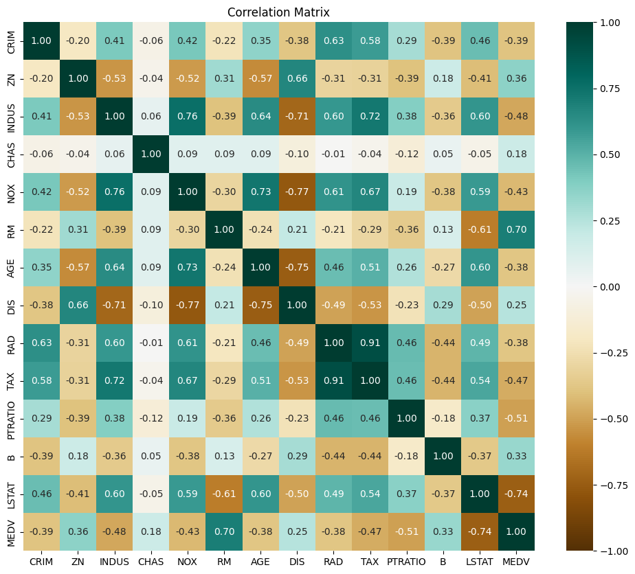

```python
%matplotlib inline

correlation_matrix = data.corr();

plt.figure(figsize=(12, 10))
sns.heatmap(correlation_matrix, annot=True, cmap='BrBG', fmt='.2f', vmin=-1, vmax=1, center=0)
plt.title('Correlation Matrix')
plt.show()
```

The correlation generated in the report may differ from the one here. By default, the corr() method in pandas uses Pearson correlation, which measures linear relationships. Reports generated by tools like ydata_profiling might use a different correlation method (Pearson, Spearman, or Kendall).

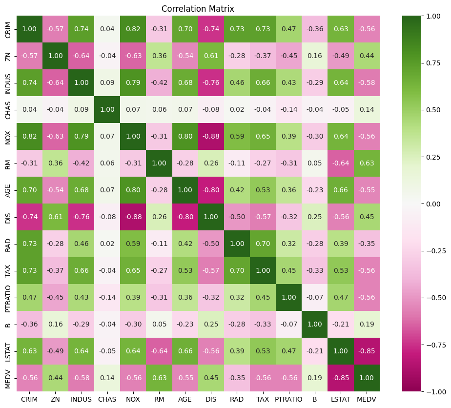

```python
%matplotlib inline

correlation_matrix = data.corr(method='spearman');

plt.figure(figsize=(12, 10))
sns.heatmap(correlation_matrix, annot=True, cmap='PiYG', fmt='.2f', vmin=-1, vmax=1, center=0)
plt.title('Correlation Matrix')
plt.show()
```

With that analyse we can see that the top 3 feature are:

- **LSTAT (Percentage of population with lower socioeconomic status): -85%**
- **RM (Average number of rooms per dwelling): 63%**
- **INDUS (Proportion of non-retail business acres per town): -58%**

**LSTAT**: The fewer people with a low socioeconomic status, the higher the housing prices tend to be.

**RM**: The more rooms there are, the larger the size of the dwelling, and consequently, the higher the price tends to be.

**INDUS**: The more industrial the area (with non-retail business land), the lower the housing prices tend to be.

These two features, LSTAT and RM, are particularly useful because they have strong correlations with MEDV, at -0.85 and 0.63, respectively.

## Part 5: Linear Regression on Boston Housing Dataset

## Simple linear regression using one feature

(RM, as specified in the lab)

### Imports needed to perform linear regression.

```python
from sklearn.model_selection import train_test_split
from sklearn.linear_model import LinearRegression
from sklearn.metrics import mean_squared_error, r2_score
```

### Create the training and test sets.

```python
X = data[['RM']]
y = data['MEDV']

X_train, X_test, y_train, y_test = train_test_split(X, y, test_size=0.3, random_state=42)
```

### Fit and predict using the linear regression model.

Calculate the scores using the mean squared error and the R² score.

```python
model = LinearRegression()
model.fit(X_train, y_train)

y_pred = model.predict(X_test)

mse = mean_squared_error(y_test, y_pred)
r2 = r2_score(y_test, y_pred)

print(f"Mean Squared Error: {mse}")
print(f"R² Score: {r2}")
```

```
Mean Squared Error: 40.35144969787305
R² Score: 0.4584649934303068
```

### Generate a graph comparing the actual and predicted values.

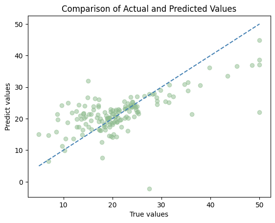

```python
plt.scatter(y_test, y_pred, alpha=0.5, color="darkseagreen")
plt.plot([min(y_test), max(y_test)], [min(y_test), max(y_test)], color='steelblue', linestyle='--')
plt.xlabel('True values')
plt.ylabel('Predict values')
plt.title('Comparison of Actual and Predicted Values')

plt.show()
```

The **MSE** of **40.351** indicates that the model's predictions have a substantial amount of error. Ideally, the MSE should be as close to 0 as possible. This relatively high MSE suggests that the model's predictions are not very accurate and that there is a significant discrepancy between the actual and predicted values.

The **R²** score of **0.458** implies that the model explains approximately 45.8% of the variance in the target variable. It indicates that the model's explanatory power is moderate. The model does not capture more than half of the variability in the data, suggesting room for improvement in predicting the target variable.

## Linear regression using multiple features

(LSTAT, RM, and INDUS)

### Create the training and test sets.

```python
X2 = data[['RM', 'LSTAT', 'INDUS']]
y2 = data['MEDV']

X_train2, X_test2, y_train2, y_test2 = train_test_split(X2, y2, test_size=0.3, random_state=42)
```

### Fit and predict using the linear regression model.

Calculate the scores using the mean squared error and the R² score.

```python
model = LinearRegression()
model.fit(X_train2, y_train2)

y_pred2 = model.predict(X_test2)

mse = mean_squared_error(y_test2, y_pred2)
r2 = r2_score(y_test2, y_pred2)

print(f"Mean Squared Error: {mse}")
print(f"R² Score: {r2}")
```

```
Mean Squared Error: 29.659612955864173
R² Score: 0.6019543580919948
```

The **R²** score of **0.60** means that the model explains approximately 60% of the variance in the target variable (MEDV). This represents an improvement from the previous explanation of 45.8%. Although this score indicates that the model captures a significant portion of the variability, 40% of the variance remains unexplained, leaving room for further improvement to better predict the target.

### Generate a graph comparing the actual and predicted values.

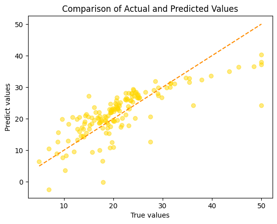

```python
plt.scatter(y_test2, y_pred2, alpha=0.5, color="gold")
plt.plot([min(y_test2), max(y_test2)], [min(y_test2), max(y_test2)], color='darkorange', linestyle='--')
plt.xlabel('True values')
plt.ylabel('Predict values')
plt.title('Comparison of Actual and Predicted Values')

plt.show()
```

## Graph comparing the two models

[figure not shown]

```python
plt.figure(figsize=(10,10), dpi=100)
plt.scatter(y_test2, y_pred2, alpha=0.5, color="lightskyblue", label="One feature")
plt.plot([min(y_test2), max(y_test2)], [min(y_test2), max(y_test2)], color='dimgray', linestyle='--')
plt.xlabel=('True values')
plt.ylabel=('Predict values')
plt.title('Comparison of Actual and Predicted Values of the two models')
plt.legend(loc='upper right')

plt.twiny()

plt.plot([min(y_test), max(y_test)], [min(y_test), max(y_test)], color='darkslategray', linestyle='--')
plt.scatter(y_test, y_pred, alpha=0.8, color="thistle", label="Multiple features (3)")

plt.legend(loc='upper left')
plt.show()
```